# ECO 395 Project: How to acquire more “kiss” on the Lovoo?

Yu-Ting Huang, Jipeng Cheng, Weidi Hou

5/8/2022

# Introduction

The importance and influence of dating apps cannot be ignored in today’s society. For example, “The Tinder Swindler” is one of the most famous movies in 2022, specially, global views was 45.8 million hours in its first week of release and hit the top 10 in 92 countries in Netflix. Furthermore, the application “Tinder - Dating New People” is super popular in the US and over 55 billion matches are made. Of course, except for Tinder, there are so many dating apps such as OkCupid, bumble, and Coffee Meets Bagel to name but a few, they have different features to attract different groups. In this study, the data from Lovoo will be analyzed. The purpose of this research is to build the model and point out what profile and specific factors can acquire more “likes” (called “kiss” on the Lovoo), as an indicator to capture the potential charisma of people. On the other hand, as we know that more “likes” means the person may get more matches and more potential encounters. The one thing that should be noticed is that our data only collects samples from “female”. Therefore, the results will be fitted for females rather than male. To have a more meaningful explanation, this study created a new variable called “conversion rate”, which can avoid the problem that the number of likes has highly correlation with the number of clicks (visit times) compared with using original `counts_kisses` as a dependent variable. Also, this indicator can effectively explain how to obtain more likes from other users by other independent variables.

`counts_kisses` = $\frac{counts\_kisses}{counts\_profileVisits}$ (1)

Throughout the series of following analysis, the consequence of this project can help many young people, who would like to make friends and/or have a pair, including our friends, classmates, and family, to have more wise strategies when using Lovoo as well as other dating app.

# Data and Methods

## Data Processing

| Variable | Description |
| --- | --- |
| age | user age |
| counts_kisses | Number of unique user accounts that “liked” (called “kiss” on the platform) this user account, following formula (1), as a index for converting times of visits to times of likes |
| counts_details | The degree of account completion |
| counts_pictures | Number of pictures on the user’s profile |
| counts_profileVisits | Number of clicks on this user (to see his/her full profile) from other user accounts |
| flirtInterests_chat | 1 if the user indicated being in search for people to chat with |
| flirtInterests_friend | 1 if the user indicated being open to making friends |
| flirtInterests_date | 1 if the user indicated being open to dating people |
| isVip | 1 if the user is VIP (this status came with benefits) |
| isVerified | Whether the user’s account was verified through one of the methods (Facebook, phone number, …) |
| lang_count | Number of languages the user knows |
| lang_fr | 1 if the user can speak French |
| lang_en | 1 if the user can speak English |
| lang_de | 1 if the user can speak German |
| lang_it | 1 if the user can speak Italian |
| lang_es | 1 if the user can speak Spanish |
| lang_pt | 1 if the user can speak Portuguese |
| freshman | 1 if the user register no more than one month |
| hasBirthday | 1 if the user has birthday |
| highlighted | 1 if the user’s profile is currently highlighted (at fetch time) |

## Model

In order to analyze which feature will help app users attract more people, we decide to **Lesso regression** and **Random Forest** methods to study it. As we all know, Lasso regression as a linear regression will give us a better fitted coefficient value. Random forest method, on the other hand, will give us a better fit but it can’t give us a good fitted coefficient value. In order to solve the above problems including in each method, we decide to combine these two methods in order to have a deep study on which characteristics will help app user attract more people.

# Results

### Lesso

Lesso approach is to make some regularization so that the regularized fit minimizes the deviance plus a **penalty** on the complexity of the estimate:$minimize_{\beta\in R} dev(\beta)/n+\lambda\times pen(\lambda)$ (2).

Here $\lambda$ is the penalty weight, while **pen** is some cost function that penalizes departures of the fitted $\beta$ from 0. In order to use **gamlr** function in r programming, we need to create our own numeric feature matrix.

### Cross-validation Lesso

Then we use cross-validation Lesso regression method so that the result will be more robust.

| Variable | beta_hat |
| --- | --- |
| intercept | -3.457606879 |
| age | 0.013822836 |
| counts_pictures | 0.004166058 |
| lang_fr | 0.040604945 |
| lang_de | -0.127865953 |

Notice that beta coefficient for the following variables including `flirtInterests_chat`, `flirtInterests_friends`, `flirtInterests_date`, `isVIP`, `isVerified`, `lang_en`, `lang_it`, `lang_es`, `lang_pt`, `countDetails`, `freshman`, `hasBirthday`, and `highlighted` are **zero**.

The result shows that the optimal $log\lambda$ which minimize the test set mean square error is -8.99 and under this level of penalty, the fitted coefficients that are not zero are `age`, `counts_pictures`, `lang_fr`, `lang_de`. From these results, we conclude that age, number of pictures on the users’ profile and proficiency in French have a positive effect on being loved by more people. However, proficiency in German has a negative effect on their level of charm. These results tell us that being mature will help people attract more people and more pictures on their app profile will also help them become popular since more pictures will tell other people more information about this themselve and help other people know the user better. In addition, people who have a good looking or who are more out-going and more confident prefer to post their picture on their app profile. These type of people also attract more people. Besides, French people are more romantic and they have a higher probability to attract more people on the app. On the other hand, German people are more serious and introverted, that’s why the fitted coefficient of knowing German is negative. In addition, from our regression result, we found that our feature matrix is very sparse (i.e, mostly zero), this is especially true since we have lots of factors as features. lasso regression is a great way to improve the efficiency of our model since it screens and ignores zero elements in actually storing X.

### Random Forest

A random forest starts from bagging. We still take B bootstrapped samples of the original data and fit a tree to each one, and we still average the predictions of the B different trees. However, it adds more randomness. With each bootstrapped sample, we don’t reach over all the features in x when we do our greedy build of a big tree. Instead, we randomly choose a subset of a features sub sample to use in building that tree. The advantages of using fewer features in each tree are that it simplifies each tree, reducing its variance and it diversifies the B trees, decorrelating their predictions.

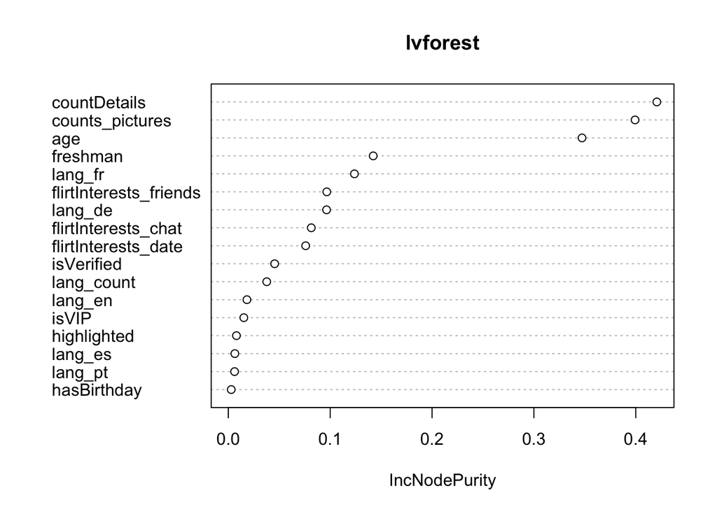

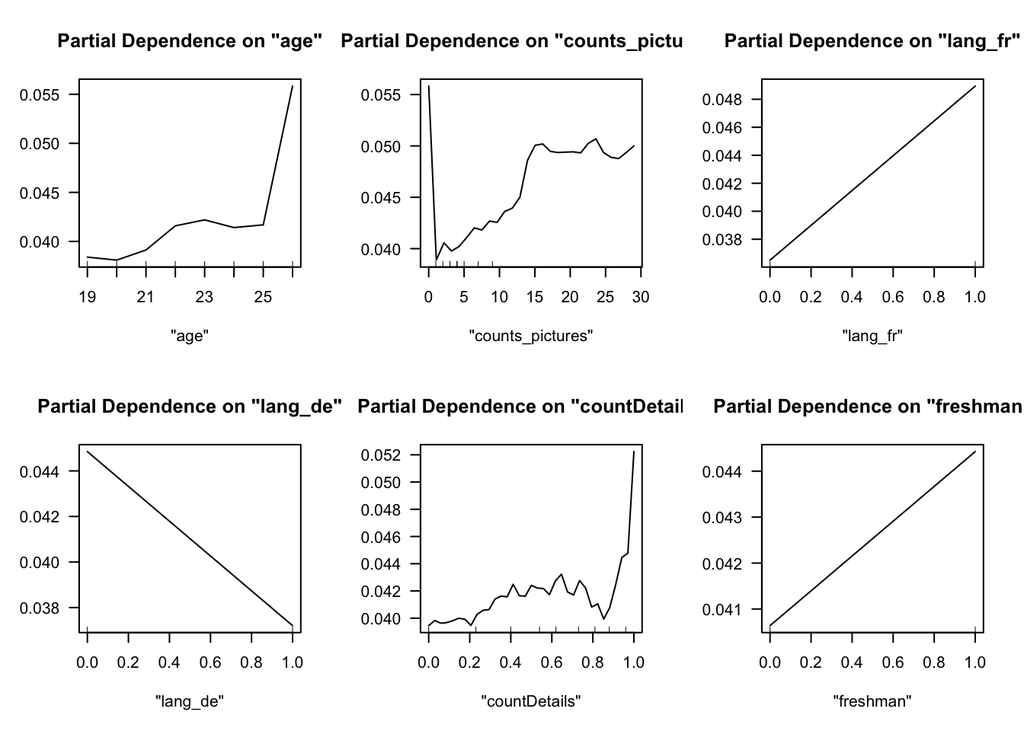

First, from the PD on `age`, we found that when people above 20 years old, they are more likely to attract people, especially when people are above 25 years old, the slope of `age` is much higher. It’s reasonable since age 20-26 is a period of dating and getting marriage so people during this age are more likely to log onto this app to find their dating mate. Second, from PD on `counts_pictures` and on `counts_Details` the result is rational since more pictures and more completed profile will tell people more stories about the user which have a positive effect on attracting more people. Third, from language perspective, people speaking French are more likely to attract people but people speaking German are less likely to attract people, since people’s characteristic are influenced by their nationality and their growing up environment. Finally, from the PD of the `freshman`, it seems that new user are more attractive, since people always like new things.

# Conclusion

As female user, in order to attract more people, they need to include more details in their profile and also post more pictures. These behaviors will provide more information about themselves. In addition, mature female seems to attract more people and new users seem to be more attractive.

# Reference

1. Tinder, https://tinder.com
2. ‘The Tinder Swindler’ Becomes First Doc To Lead Netflix’s Weekly Film Chart, https://deadline.com/2022/02/the-tinder-swindler-first-doc-lead-netflixs-weekly-film-chart-1234928573/
3. Lovoo, https://about.lovoo.com/en/#app-features